# Question 1

```r
library(tidyverse)
library(gapminder)
# use ?gapminder get the desciption of the dataset `gapminder`
```

Consider the dataset `gapminder`.

##### (a) Modify the `continent` factor by classifying the Americas’ countries into `South America` and `North America`

````
Hint: the following countries are in South America.
```r
c("Argentina", "Bolivia", "Brazil", "Chile", "Colombia", "Ecuador", "Paraguay", "Peru", "Trinidad and Tobago", "Uruguay", "Venezuela")
```
````

```r
my_gap=gapminder %>%
  mutate(continent=case_when(
    country %in%c("Argentina", "Bolivia", "Brazil", "Chile", "Colombia", "Ecuador", "Paraguay", "Peru", "Trinidad and Tobago", "Uruguay", "Venezuela")~"South America",
    continent=="Americas"~"North America",
   TRUE ~ as.character(continent))
    )
```

In the following questions, use the dataset modified in (a).

Hint: you could use `case_when` function.

##### (b) How many countries are there in the dataset? How about for each continent?

```r
my_gap %>%
  summarize(totalcountries = n_distinct(country))
```

```
## # A tibble: 1 x 1
##   totalcountries
##            <int>
## 1            142
```

```r
my_gap %>%
  group_by(continent) %>%
  summarize(n = n(),
            n_countries = n_distinct(country))
```

```
## # A tibble: 6 x 3
##   continent         n n_countries
##   <chr>         <int>       <int>
## 1 Africa          624          52
## 2 Asia            396          33
## 3 Europe          360          30
## 4 North America   168          14
## 5 Oceania          24           2
## 6 South America   132          11
```

There are 142 countries in the dataset. Africa has 52 countries.Asia has 33 countries. Europe has 30 countries.Oceania has 2 countries. North America has 14 countries. South America has 11 countries.

##### (c) For each year, which country had the largest gdp per capital?

```r
my_gap %>%
   arrange(year) %>%
  group_by(year) %>%
  top_n(1,wt=(gdpPercap))
```

```
## # A tibble: 12 x 6
## # Groups:   year [12]
##    country      continent  year lifeExp      pop gdpPercap
##    <fct>        <chr>     <int>   <dbl>    <int>     <dbl>
##  1 Kuwait       Asia       1952    55.6   160000   108382.
##  2 Kuwait       Asia       1957    58.0   212846   113523.
##  3 Kuwait       Asia       1962    60.5   358266    95458.
##  4 Kuwait       Asia       1967    64.6   575003    80895.
##  5 Kuwait       Asia       1972    67.7   841934   109348.
##  6 Kuwait       Asia       1977    69.3  1140357    59265.
##  7 Saudi Arabia Asia       1982    63.0 11254672    33693.
##  8 Norway       Europe     1987    75.9  4186147    31541.
##  9 Kuwait       Asia       1992    75.2  1418095    34933.
## 10 Norway       Europe     1997    78.3  4405672    41283.
## 11 Norway       Europe     2002    79.0  4535591    44684.
## 12 Norway       Europe     2007    80.2  4627926    49357.
```

Answer 1952,1957,1962,1967,1972,1977: Kuwait 1982:Saudi Arabia 1987:Norway 1992:Kuwait 1997:Norway

##### (d) For each continent, which country experienced the sharpest increment rate in life expectancy from 1997 to 2007?

```r
gapminder1997 <- my_gap %>% filter(year==1997) %>% select(country, continent,  lifeExp) %>%
    rename(lifeExp1997=lifeExp)
gapminder2007 <- my_gap %>% filter(year==2007) %>% select(country, continent,  lifeExp) %>%
    rename(lifeExp2007=lifeExp)
dat <- inner_join(gapminder1997, gapminder2007)
dat$rate <- (dat$lifeExp2007-dat$lifeExp1997)/dat$lifeExp1997
dat %>% group_by(continent) %>% arrange(desc(rate)) %>% slice(1)
```

```
## # A tibble: 6 x 5
## # Groups:   continent [6]
##   country     continent     lifeExp1997 lifeExp2007   rate
##   <fct>       <chr>               <dbl>       <dbl>  <dbl>
## 1 Rwanda      Africa               36.1        46.2 0.281
## 2 Yemen, Rep. Asia                 58.0        62.7 0.0806
## 3 Albania     Europe               73.0        76.4 0.0476
## 4 Haiti       North America        56.7        60.9 0.0749
## 5 New Zealand Oceania              77.6        80.2 0.0342
## 6 Bolivia     South America        62.0        65.6 0.0565
```

Answer:New Zealand in Oceania, Haiti in North America,Bolivia in South America,Albania in Europe, emen, Rep. in Asia, Rwanda in Africa have the highest life expectency increment rate from 1997 to 2007

##### (e) Focus on the data in year 2007, what are the correlation coefficients between life expectancy and gdp per capital for each continent?

```r
my_gap %>% filter(year==2007) %>%
           group_by(continent) %>%
           summarize(cor(lifeExp,gdpPercap))
```

```
## # A tibble: 6 x 2
##   continent     `cor(lifeExp, gdpPercap)`
##   <chr>                             <dbl>
## 1 Africa                            0.385
## 2 Asia                              0.689
## 3 Europe                            0.850
## 4 North America                     0.645
## 5 Oceania                           1
## 6 South America                     0.362
```

##### (f) Visualize part (e) by plotting gdp per capital vs life expectancy.

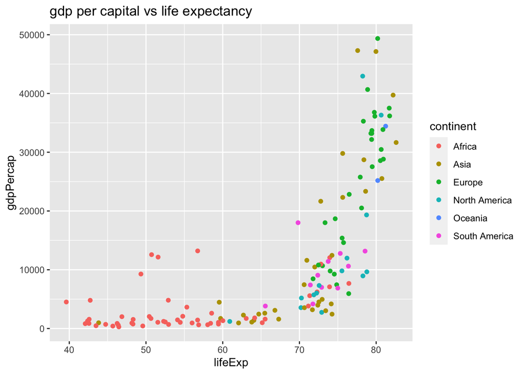

```r
my_gap_2007=my_gap %>% filter(year==2007)
ggplot(my_gap_2007,aes(x=lifeExp,y=gdpPercap,color=continent))+geom_point()+ggtitle( "gdp per capital vs life expectancy")+xlab("lifeExp")+ylab("gdpPercap")
```